# Publication Figure 6

# Libraries

Standard Import

```r
library(tidyverse)
library(cowplot)
library(scales)
library(ggpubr)
```

Special

```r
# devtools::install_github("pmartinezarbizu/pairwiseAdonis/pairwiseAdonis")
# library(rgr)
# library(mixOmics)
library(pairwiseAdonis)
library(grid)
library(factoextra)
library(FactoMineR)
```

# Paths

```r
bin_dir = '../bin/'
data_dir = '../data/'
results_dir = '../results/'
```

# Custom Scripts / Theme

```r
source(paste0(bin_dir, 'theme_settings.R'))
source (paste0(bin_dir, 'utilities.R'))
source(paste0(bin_dir, 'species_competition_functions.R'))
source(paste0(bin_dir, 'distmat_utils.R'))
source(paste0(bin_dir, 'analysis_metadata.R'))
date <- format(Sys.time(), "%d%m%y")
```

# Import Tables

Metadata

```r
samples.metadata <- read_tsv(paste0(data_dir, 'samples.metadata.tsv'))
microbe.taxonomy <- read_tsv(paste0(data_dir, 'microbe.taxonomy.tsv'))
microbe.metadata <- microbe.taxonomy %>%
  right_join(., read_tsv(paste0(data_dir, 'microbe.metadata.tsv'))) %>%
  mutate(gram.bool = ifelse(gram_stain == 'positive', T,
                     ifelse(gram_stain == 'negative', F, NA)),
         spores.bool = ifelse(spore_forming == 'spore-forming', T,
                       ifelse(spore_forming == 'non-spore-forming', F, NA)))
```

## Taxonomy

MetaPhlAn2 tables combine with taxonomy

```r
mp_species.long <- microbe.taxonomy %>%
  right_join(., read_tsv(paste0(data_dir, 'samples.mp_profiles.species.tsv')),
             by = 'species') %>%
  left_join(., samples.metadata, by = 'Name')
```

rCDI subset annotate with metadata

```r
mp_species.rcdi.long <-
  mp_species.long %>%
  filter(Study %in% c(rcdi.studies))
```

## Case Summary

SameStr Case-Summary table

```r
sstr_cases <- read_tsv(paste0(data_dir, 'samples.case_summary.tsv')) %>%
  left_join(., microbe.taxonomy, by = 'species')
```

# Set Figure

```r
fig = paste0('Fig_6.')
```

# Failed/Resolved Symptoms

Focussing on the difference between successful FMT cases and cases in which symptoms were reported to no have been resolved after FMT treatment.

## %Recipient/Donor-derived

### Format Data

```r
sstr_cases.rcdi.metrics <-
  sstr_cases %>%

  filter(Study %in% c('ALM', 'FRICKE')) %>%
  filter(Case_Name %in% cases.full) %>%

  tag_species_competition(.) %>%

  mutate(n = 1) %>%
  mutate(source = ifelse(grepl(species, pattern = 'unclassified'),  'Unclassified', source)) %>%

  mutate(source = case_when(
  analysis_level == 'species' & source == 'self' ~ 'Self Sp.',
  analysis_level == 'species' & source == 'donor' ~ 'Donor Sp.',
  analysis_level == 'species' & source == 'unique' ~ 'Unique Sp.',
  T ~ source
  )) %>%

  group_by(Study_Type, Case_Name, source, Days_Since_FMT.post, fmt_success.label) %>%
  summarize(n = sum(n, na.rm = T),
            rel_abund = sum(rel_abund.post, na.rm = T) / 100) %>%
  group_by(Case_Name, Days_Since_FMT.post) %>%
  mutate(f = n / sum(n, na.rm = T)) %>%
  ungroup() %>%

  group_by(Case_Name) %>%
  mutate(source = case_when(source == 'Unclassified' ~ 'Unclassified Sp.',
                  source == 'same_species' ~ 'Same Sp.',
                  source == 'unique' ~ 'Unique to Time Point',
                  source == 'self' ~ 'Recipient / Initial Sample',
                  source == 'donor' ~ 'Donor',
                  source == 'both' ~ 'Coexistence',
                  T ~ source)) %>%

  pivot_wider(names_from = 'source',
               values_from = c('rel_abund','f', 'n'), names_sep = '___') %>%
  mutate_at(.vars = vars(contains('___')),
            .funs = funs(replace_na(., 0))) %>%
  pivot_longer(cols = contains("___"),
               names_to = c("metric", "source"),
               names_sep = '___', values_drop_na = F) %>%
  mutate(fmt_success.label = ifelse(fmt_success.label == 'Failed',
                                    'Unresolved Symptoms', 'Resolved Symptoms'))
```

```r
sstr_cases.rcdi.rel_abund.annotated <-
  sstr_cases.rcdi.metrics %>%
  filter(metric == 'rel_abund') %>%
  filter(Days_Since_FMT.post <= 37) %>%

  # keep only recipient and donor-derived (excluding coexistence)
  mutate(
    source.simple = case_when(
           source %in% c('Recipient / Initial Sample','Self Sp.') ~ 'Recipient',
           source %in% c('Donor','Donor Sp.') ~ 'Donor',
           T ~ 'Drop'
         )) %>%
  filter(source.simple != 'Drop') %>%

  group_by(Case_Name, Days_Since_FMT.post, source.simple, fmt_success.label) %>%
  summarize(value = sum(value, na.rm = T)) %>%
  ungroup()
```

### Scatterplot over time

Fraction of donor and recipient-derived species over time for failed and resolved cases

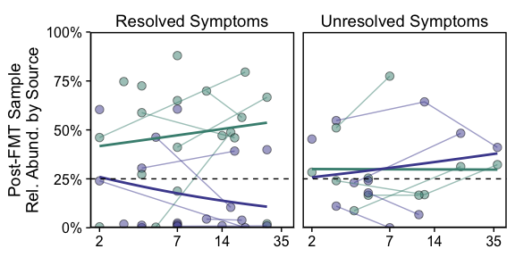

```r
plot <-
  sstr_cases.rcdi.rel_abund.annotated %>%


  ggplot(aes(Days_Since_FMT.post, value)) +
  geom_point(aes(fill = source.simple), alpha = 0.5,
             shape = 21, size = 3, col = 'black') +
  geom_line(aes(col = source.simple,
                group = paste0(Case_Name, source.simple)
                ), show.legend = F, alpha = 0.5) +
  geom_smooth(se = F, method = 'glm', aes(col = source.simple),
              method.args=list(family='binomial')) +
  geom_hline(yintercept = 0.25, linetype = 'dashed', size = .5) +

  scale_color_manual(values = colors.discrete[c(1,3)]) +
  scale_fill_manual(values = colors.discrete[c(1,3)]) +
  scale_y_continuous(labels = percent_format_signif,
                     breaks = c(0, .25, .5, .75, 1),
                     limits = c(0, 1), expand = c(0,0)) +
  scale_x_continuous(trans = pseudo_log_trans(0.5, 10),
                     breaks = c(2, 7, 14, 35, 84, 365)) +
  facet_grid(cols = vars(fmt_success.label)) +
  theme_cowplot() +
  theme(axis.title.x = element_blank(),
        axis.line = element_line(size = 0.2, color = 'black'),
        strip.text.x = element_text(size = 14),
        strip.background = element_blank()) +
  panel_border(remove = F, size = 1, color = 'black') +
  labs(y = 'Post-FMT Sample\nRel. Abund. by Source') +
  guides(fill = guide_legend(title = 'Post-FMT\nMicrobiota Source', ncol = 1))

plot + theme(legend.position = 'none')
```

```r
legend = cowplot::get_legend(plot)
```

```
non-integer #successes in a binomial glm!non-integer #successes in a binomial glm!non-integer #successes in a binomial glm!non-integer #successes in a binomial glm!
```

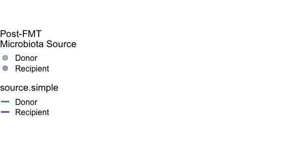

```r
grid.newpage()
grid.draw(legend)
```

Exporting plot

```r
output_name = 'PostSource.Cases.Time.rCDI'

ggsave(plot + theme(legend.position = 'none'),
       device = 'pdf', dpi = 300, width = 6, height = 3,
       filename = paste0(results_dir, fig, output_name, '.Plot.pdf'))
ggsave(legend,
       device = 'pdf', dpi = 300, width = 3, height = 3,
       filename = paste0(results_dir, fig, output_name, '.Legend.pdf'))
```

Persistence / Engraftment within time periods:

```r
sstr_cases.rcdi.rel_abund.annotated %>%
  filter(Days_Since_FMT.post > 0, Days_Since_FMT.post <= 7) %>%
  group_by(source.simple, fmt_success.label) %>%
  summarize(mean = mean(value) * 100,
            sd = sd(value) * 100,
            .groups = 'drop')
```

| source.simple | fmt_success.label | mean | sd |
| --- | --- | --- | --- |
| Donor | Resolved Symptoms | 44.80902 | 30.11514 |
| Donor | Unresolved Symptoms | 33.09194 | 23.51821 |
| Recipient | Resolved Symptoms | 20.88801 | 24.85951 |
| Recipient | Unresolved Symptoms | 25.15030 | 19.03427 |

```r
sstr_cases.rcdi.rel_abund.annotated %>%
  filter(Days_Since_FMT.post > 7, Days_Since_FMT.post <= 37) %>%
  group_by(source.simple, fmt_success.label) %>%
  summarize(mean = mean(value) * 100,
            sd = sd(value) * 100,
            .groups = 'drop')
```

| source.simple | fmt_success.label | mean | sd |
| --- | --- | --- | --- |
| Donor | Resolved Symptoms | 52.03675 | 23.550714 |
| Donor | Unresolved Symptoms | 24.27240 | 8.648177 |
| Recipient | Resolved Symptoms | 12.49065 | 17.006038 |
| Recipient | Unresolved Symptoms | 40.08954 | 24.284422 |

Resolved: Donor -> 44.8 ± 30.1 to 52.0 ± 23.6 Recipient -> 20.9 ± 24.9 to 12.5 ± 17.0

Failed: Donor -> 33.1 ± 23.5 to 24.3 ± 8.7 Recipient -> 25.2 ± 19.0 to 40.1 ± 24.3

### Boxplot

Boxplots at <=1W, 1-6W, >6W

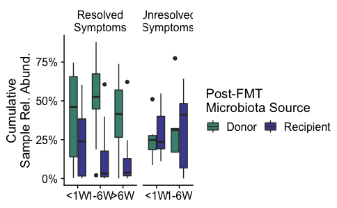

```r
sstr_cases.rcdi.metrics %>%
  filter(metric == 'rel_abund') %>%
  mutate(Days_Since_fmt_success.label = case_when(
    Days_Since_FMT.post <7 ~ '<1W',
    Days_Since_FMT.post >=7 & Days_Since_FMT.post <= 42 ~ '1-6W',
    Days_Since_FMT.post > 42 ~ '>6W')) %>%

  # keep only recipient and donor-derived (excluding coexistence)
  mutate(
    source.simple = case_when(
           source %in% c('Recipient / Initial Sample','Self Sp.') ~ 'Recipient',
           source %in% c('Donor','Donor Sp.') ~ 'Donor',

           T ~ 'Drop'
         )) %>%
  filter(source.simple != 'Drop') %>%

  group_by(Case_Name, Days_Since_FMT.post, Days_Since_fmt_success.label, source.simple, fmt_success.label) %>%
  summarize(value = sum(value, na.rm = T)) %>%
  ungroup() %>%

  mutate(Days_Since_fmt_success.label = fct_relevel(Days_Since_fmt_success.label, '<1W', '1-6W', '>6W')) %>%

  ggplot(aes(Days_Since_fmt_success.label, value, fill = source.simple)) +
  geom_boxplot() +
  scale_y_continuous(labels = percent_format_signif) +
  facet_grid(cols = vars(gsub(fmt_success.label, pattern = ' ', replacement = '\n')),
             space = 'free', scales = 'free_x') +
  theme_cowplot() +
  theme(axis.title.x = element_blank(),
        strip.background = element_blank()) +
  scale_fill_manual(values = colors.discrete[c(1,3)]) +
  labs(y = 'Cumulative\nSample Rel. Abund.') +
  guides(fill = guide_legend(title = 'Post-FMT\nMicrobiota Source', ncol = 2))
```

## Diversity Differences

### Alpha: Shannon

#### Format

```r
# transpose
mp_species.wide <- mp_species.long %>%
  filter(kingdom == 'Bacteria',
         Study_Type == 'rCDI') %>%
  pivot_wider(id_cols = 'species',
              names_from = 'Name',
              values_from = 'rel_abund',
              values_fill = list(rel_abund = 0))

# alpha diversity
mp_species.samples <- t(select(mp_species.wide, matches('.pair'), species) %>% column_to_rownames(var = 'species'))
mp_species.shannon <- data.frame(Shannon = diversity(mp_species.samples, index = 'shannon')) %>% rownames_to_column('Name') %>%
left_join(., samples.metadata, by = 'Name')
```

#### Boxplots

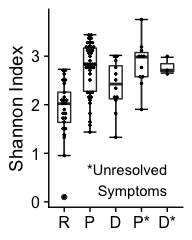

```r
ww = 0.5
plot <-
  mp_species.shannon %>%
  filter(!is.na(Sample_Type)) %>%
  # filter(last_sample) %>%

  mutate(Sample_Type.label = str_to_upper(unlist(str_extract(Sample_Type, '.')))) %>%
  mutate(tag = case_when(
    Donor.Subject != 'D0_ALM_Case_4;5;6;8;9;12;13;15;17;18;20;21' ~ Sample_Type.label,
    Donor.Subject == 'D0_ALM_Case_4;5;6;8;9;12;13;15;17;18;20;21' &
      (Sample_Type == 'donor' | (Sample_Type == 'post' & !fmt_success)) ~ paste0(Sample_Type.label, '*'),
    T ~ Sample_Type.label
  )) %>%
  mutate(tag = fct_relevel(tag, 'R', 'P', 'D', 'P*', 'D*')) %>%
  # filter(tag != 'R') %>%

  ggplot(aes(tag, Shannon)) +
  stat_boxplot(geom = 'errorbar', width = ww) +
  geom_boxplot(show.legend = F, width = ww) +
  geom_dotplot(aes(fill = NULL), binaxis = "y",
               stackdir = "center", binpositions="all", binwidth = 0.05) +

  theme_cowplot() +
  theme(axis.title.x = element_blank()) +
  labs(y = 'Shannon Index') +
  annotate('text', label = '*Unresolved\nSymptoms', y = 0.45, x = 'D*', hjust = 1) # +
  # stat_compare_means(method = 'kruskal')

plot
```

Exporting plot

```r
output_name = 'TaxonomicDiversity.Shannon'

ggsave(plot + theme(legend.position = 'none'),
       device = 'pdf', dpi = 300, width = 2, height = 2.5,
       filename = paste0(results_dir, fig, output_name, '.Plot.pdf'))
```

### Beta: PCA of species-level taxonomic composition

PCA of clr-transformed taxonomic composition

#### Diversity Calculations

```r
# transpose
mp_species.rcdi.wide <- mp_species.rcdi.long %>%
  filter(kingdom == 'Bacteria') %>%
  pivot_wider(id_cols = 'species',
              names_from = 'Name',
              values_from = 'rel_abund',
              values_fill = list(rel_abund = 0))

## -- genus-level
mp_genus.rcdi.wide <- mp_species.rcdi.long %>%
  filter(kingdom == 'Bacteria') %>%
  pivot_wider(id_cols = 'genus',
              names_from = 'Name',
              values_from = 'rel_abund',
              values_fill = list(rel_abund = 0),
              values_fn = list(rel_abund = sum))

# get data
mp_species.rcdi.data <- t(select(mp_species.rcdi.wide,
                                    matches('.pair'), species) %>%
                               column_to_rownames(var = 'species'))

## -- genus
mp_genus.rcdi.data <- t(select(mp_genus.rcdi.wide,
                                    matches('.pair'), genus) %>%
                               column_to_rownames(var = 'genus'))

# species-level
pseudo = 1e-6
mp_species.rcdi.clr <- rgr::clr(mp_species.rcdi.data + pseudo,  ifclose = FALSE, ifwarn = TRUE)
```

```
  ** Are the data/parts all in the same measurement units? **
```

```r
# aitchison dist
mp_species.rcdi.clr.dist <- dist(scale(mp_species.rcdi.clr, center = T, scale = F),
                                 method = 'euclidean') %>% as.matrix()

# pca
mp_species.rcdi.clr.pca_data <- PCA(mp_species.rcdi.clr, graph = FALSE, scale.unit = F)
mp_species.rcdi.clr.pca <- mp_species.rcdi.clr.pca_data %>%
  .$ind %>% .$coord %>%
  as.data.frame() %>%
  rownames_to_column(var = 'Name')

## annotate with metadata, diversity
mp_species.rcdi.data.clr.pca <- mp_species.rcdi.clr.pca %>%
  left_join(., samples.metadata, by = c('Name')) %>%
  left_join(., mp_species.shannon %>% select(Name, Shannon), by = c('Name')) %>%
  group_by(Case_Name, Sample_Type) %>%
  mutate(last = dense_rank(Days_Since_FMT) == max(dense_rank(Days_Since_FMT))) %>%
  mutate(d3.tag = case_when(
    Donor.Subject == 'D0_ALM_Case_4;5;6;8;9;12;13;15;17;18;20;21' & Sample_Type == 'post' ~
      paste0('post | D3 ', if_else(fmt_success, 'Success', 'Failed')),
    Donor.Subject == 'D0_ALM_Case_4;5;6;8;9;12;13;15;17;18;20;21' & Sample_Type == 'donor' ~ 'donor | D3',
    T ~ Sample_Type)) %>%
  ungroup()
```

#### D/P Difference

PERMANOVA (adonis function) testing between rCDI Donors & Post-FMT: MGH03D with failed cases (3 samples) and other donors.

```r
# donor & post-FMT
selection <- mp_species.rcdi.long %>%
  filter(Sample_Type %in% c('post', 'donor'), last_sample) %>%
  distinct(Name, Donor.Subject, Sample_Type, fmt_success)

d3.adonis <-
  pairwiseAdonis::pairwise.adonis(
  x = mp_species.rcdi.clr[selection$Name, ],
  factors = ifelse(selection$Donor.Subject == "D0_ALM_Case_4;5;6;8;9;12;13;15;17;18;20;21", 'MGH03D-related','Other'),
  sim.method = 'euclidean',
  perm = 1e3) %>%
  rename(fdr = p.adjusted) %>%
  mutate(sig = cut(fdr,
                   breaks = c(-Inf, 0.001, 0.01, 0.05, Inf),
                   labels = c("***", "**", "*", "ns")))

d3.adonis
```

| pairs | Df | SumsOfSqs | F.Model | R2 | p.value | fdr | sig |
| --- | --- | --- | --- | --- | --- | --- | --- |
| Other vs MGH03D-related | 1 | 35811.13 | 6.661916 | 0.1427699 | 0.000999001 | 0.000999001 | *** |

#### PCA biplot

##### Format

Abbr. species names in PCA object

```r
select.prevotella <- c('Prevotella_denticola', 'Prevotella_oris', 'Prevotella_oralis','Prevotella_veroralis')
select.fusobacteria <- c('Fusobacterium_nucleatum', 'Fusobacterium_periodonticum', 'Fusobacterium_mortiferum')
other <-  c('Rothia_dentocariosa', 'Veilonella_parvula')

select.bacteroides <- c('Bacteroides_faecis', 'Bacteroides_eggerthii', 'Bacteroides_intestinalis', 'Bacteroides_thetaiotaomicron')
# 'Bacteroides_fragilis',
select.ruminococcus <- c('Ruminococcus_torques', 'Ruminococcus_gnavus')
# 'Ruminococcus_albus', 'Ruminococcus_callidus', 'Bacteroides_obeum'

plot_spp <- c(other, select.bacteroides, select.ruminococcus, select.prevotella, select.fusobacteria,
               'Lachnospiraceae_bacterium')

print_taxonomy <- function(name, selection) {
  unlist(
    lapply(name, function(x) {
      case_when(
        !x %in% selection ~ x,
        x %in% selection ~ str_replace(str_replace(x, '_', ' '), '[a-z].*\ ', '. ')
      )
    }
    )) %>%
    return()
}

rownames(mp_species.rcdi.clr.pca_data$var$coord) <- print_taxonomy(rownames(mp_species.rcdi.clr.pca_data$var$coord), plot_spp)
rownames(mp_species.rcdi.clr.pca_data$var$cor) <- print_taxonomy(rownames(mp_species.rcdi.clr.pca_data$var$cor), plot_spp)
rownames(mp_species.rcdi.clr.pca_data$var$cos) <- print_taxonomy(rownames(mp_species.rcdi.clr.pca_data$var$cos), plot_spp)
rownames(mp_species.rcdi.clr.pca_data$var$contrib) <- print_taxonomy(rownames(mp_species.rcdi.clr.pca_data$var$contrib), plot_spp)
```

```r
# https://stackoverflow.com/questions/13407236/remove-a-layer-from-a-ggplot2-chart
remove_geom <- function(ggplot2_object, geom_type) {
  # Delete layers that match the requested type.
  layers <- lapply(ggplot2_object$layers, function(x) {
    if (class(x$geom)[1] == geom_type) {
      NULL
    } else {
      x
    }
  })
  # Delete the unwanted layers.
  layers <- layers[!sapply(layers, is.null)]
  ggplot2_object$layers <- layers
  ggplot2_object
}
```

```r
pp <-
  factoextra::fviz_pca_biplot(mp_species.rcdi.clr.pca_data,
             # samples
             fill.ind = mp_species.rcdi.data.clr.pca$d3.tag,
             pointshape = 21,
             pointsize = 8,
             alpha.ind = ifelse(grepl(mp_species.rcdi.data.clr.pca$d3.tag, pattern = 'D3'), 1, .25),

             # features
             select.var = list('name' = print_taxonomy(plot_spp, plot_spp)),
             label = 'var', labelsize = 3,
             col.var = 'black',
             repel = T, invisible = c("quali"),

             # general
             addEllipses = F, centroids = F, scale = F,
             title = '',
             subtitle = 'Taxonomic Composition',
             )  +

  ggpubr::fill_palette(palette = c(colors.discrete[c(1,1,2)],
                                   '#B4907E',  #A47963
                                   colors.discrete[c(2,3)])) +
  scale_x_reverse() +
  scale_y_reverse() +
  theme_cowplot() +
  theme(aspect.ratio = 1,
        plot.subtitle = element_text(hjust = .5, size = 12),
        axis.title = element_text(size = 10),
        axis.text = element_text(size = 8),
)  +
  coord_flip()
```

```
Ignoring unknown parameters: scalethe condition has length > 1 and only the first element will be used
```

```r
# axes - rename
pp$labels$x <- str_replace(pp$labels$x, pattern = 'Dim', replacement = 'PC ')
pp$labels$y <- str_replace(pp$labels$y, pattern = 'Dim', replacement = 'PC ')

# arrows - rescale
pp[["layers"]][[5]][["data"]][["x"]] = pp[["layers"]][[5]][["data"]][["x"]]  *.4
pp[["layers"]][[5]][["data"]][["y"]] = pp[["layers"]][[5]][["data"]][["y"]]  *.4

# labels
pp[["layers"]][[4]][["data"]][["x"]] = pp[["layers"]][[4]][["data"]][["x"]]  *.4
pp[["layers"]][[4]][["data"]][["y"]] = pp[["layers"]][[4]][["data"]][["y"]]  *.4

# crosshair
pp <- remove_geom(pp, 'GeomHline')
pp <- remove_geom(pp, 'GeomVline')

pp <- pp +
  annotate('text', x = -52, y = 52, hjust = 0, vjust = 1, size = 3,
           label = paste0('PERMANOVA (Post-FMT & Donors)\n',
                         'MGH03D-related vs. Others\n')) +
  annotate('text', x = -41.5, y = 52, hjust = 0, vjust = 1, size = 3,
           label = bquote(R^2 * '=' *  .(format(100*d3.adonis$R2,digits=3))*'%' * .(format(d3.adonis$sig))))

legend <- cowplot::get_legend(pp)
```

```
is.na() applied to non-(list or vector) of type 'language'
```

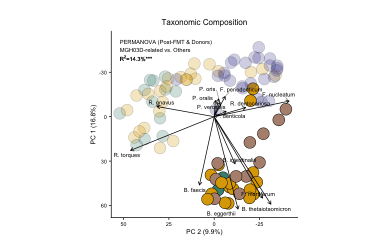

```r
pp + theme(legend.position = 'none')
```

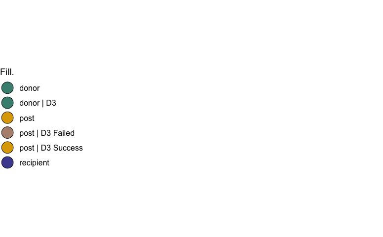

```r
grid.newpage()
grid.draw(legend)
```

Exporting plot

```r
output_name = 'TaxonomicDiversity.rCDI.CLR_PCAbiplot'

ggsave(pp + theme(legend.position = 'none'),
       device = 'pdf', dpi = 300, width = 5, height = 5,
       filename = paste0(results_dir, fig, output_name, '.Plot.pdf'))
ggsave(legend,
       device = 'pdf', dpi = 300, width = 5, height = 5,
       filename = paste0(results_dir, fig, output_name, '.Legend.pdf'))
```